# Worksheet 3 - Scientific Visualization MVE080/MMG640

## Images, contours, vector fields, and stream lines

Name: Elvina Fahlgren

This is the third worksheet in the course *Scientific Visualization*. The purpose is to learn about how 2D images are represented on the computer, different types of image file formats, how to visualize images in Matplotlib, and the concepts of contour, vector field, and steam line plots.

Once you're finished with all the tasks, export this document as an HTML-file and upload it in Canvas. You are encouraged to discuss problems and solutions with your fellow students (in the class-room but also on CampusWire), but each student must solve all tasks by themselves and hand-in their own report. Notice that Jupyter notebooks use [Markdown](https://docs.github.com/en/github/writing-on-github/getting-started-with-writing-and-formatting-on-github/basic-writing-and-formatting-syntax#links) for writing text cells. Make sure you understand the basics. Later on you can also include $\LaTeX$ in your Markdown cells.

## Setup

Before we begin it is necessary to load a few Python modules that are needed. We can do that with the following commands (which only have to be run once, unless you restart the Jupyter kernel in which case you have to re-run them).

```python
import numpy as np
import matplotlib.pyplot as plt
import matplotlib.image as mpimg
import seaborn as sns
%matplotlib inline
```

## Task 1: images

Read Chapters 27 of [Fundamentals of Data Visualizations](https://clauswilke.com/dataviz/), then answer the questions below.

### Question 1.1

What is the difference between vector and bitmap images? Can one always convert between the two?

### Answer 1.1

A vector image is structured by geometric arrangment of induvidual graphical elements. Each point, x and y coordinate, in a vector image is drawn when the image is rendered. And a bitmap image contain induvidual points (pixels) stored in a grid.

Generally, it is possible to always convert between a vector graphic and a bitmap image. However, when converting a vector graphic into a bitmap format, e.g. a pdf as a png, the key feature of the vecotr graphic (the resolution independence) is lost. And when converting a bitmap image into a vector graphic, the image will still be a bitmap image stored inside a vector gaphic.

### Question 1.2

What does *compression* of an image mean? What is the difference between lossless and lossy compression?

### Answer 1.2

*Compression* of an image imply the byte minimizing of the graphical file without degrading the image quality to an unaccaptable level, and the file can be decompressed again to the large file.

Lossless compression refers to compression in which the compressed images is pixel-for-pixel identical to the original image. The image is reduced without any quality loss. By lossy compression the image will lose data.

When a lossless compressed image is restored to its original form, no loss of data occurs. On the contrary, when a lossy compressed image is restored to its original form, data is lost.

### Question 1.3

What is the meaning of *color channels*? Describe how this is related to how a (raw) bitmap image is stored in memory.

### Answer 1.3

By combinidig the red, green and blue *color channels* with different intensities we can get any color we want. Each pixel in a bitmap is represented and stored by these intensities of red, green and blue called *RGB color model*. If we want a pixel to be black, the pixel is stored as [0, 0, 0].

### Task 1.1

Study the Matplotlib [Image tutorial](https://matplotlib.org/stable/tutorials/index.html). Then take a photo with your phone and save it to you computer.

Write code below for loading and displaying your image using Matplotlib (or the module [Pillow](https://pillow.readthedocs.io) if you prefer, which Matplotlib is using internally).

[output not shown]

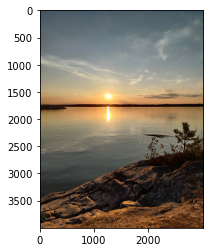

```python
# Your code-cells here
img = mpimg.imread('img_worksheet3.jpg')
print(img)
imgplot = plt.imshow(img)
```

### Task 1.2

Convert your image to a grayscale (single channel) image. Display it using three different Matplotlib [colormaps](https://matplotlib.org/stable/tutorials/colors/colormaps.html#sphx-glr-tutorials-colors-colormaps-py). One of the colormaps should be the Cubehelix map (palette) that you created in Work-sheet 2. Also add [colorbars](https://matplotlib.org/stable/api/_as_gen/matplotlib.pyplot.colorbar.html#matplotlib.pyplot.colorbar) to your plots.

**Hint:** To make Seaborn return a Matplotlib *colormap* instead of a Seaborn *palette*, use the argument `as_cmap=True`.

```python
gray_img = np.dot(img, [0.2989, 0.5870, 0.1140])
```

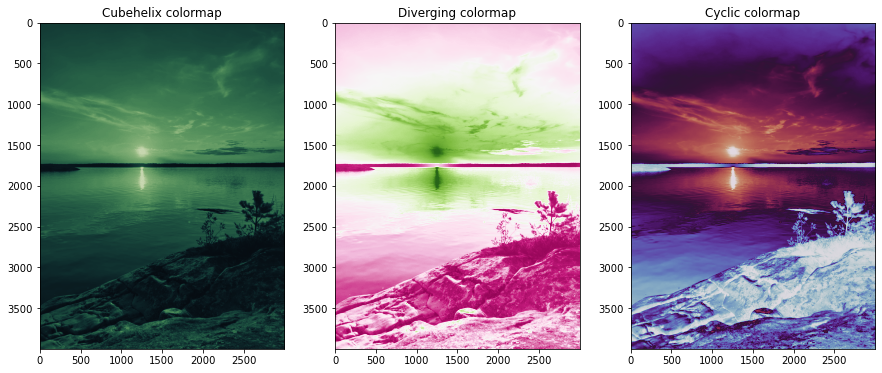

```python
# cubehelix_palette from worksheet 2
cubehelix_palette = sns.cubehelix_palette(start = 3, rot =-0.5, gamma = 2, hue = .8, light = .9, dark = .20, reverse = True, as_cmap=True)

plt.figure(figsize=(15, 6))

plt.subplot(131)
plt.imshow(gray_img, cmap = cubehelix_palette)
plt.title("Cubehelix colormap")

plt.subplot(132)
plt.imshow(gray_img, cmap = 'PiYG')
plt.title("Diverging colormap")

plt.subplot(133)
plt.imshow(gray_img, cmap = 'twilight')
plt.title("Cyclic colormap")

plt.show()
```

### Task 1.3

The task is the following:

- Create a grayscale image representing the function $f:[-\pi,\pi]\times[0,1]\to [-1,1]$ defined by $f(x,y) = y*\cos(x/2)$. The resolution should be 1024 * 512. Let the value -1.0 correspond to 0 and 1.0 to 255.
- Save your image as a JPEG image in two versions: first using the `gray` colormap then using your own Cubehelix colormap.
- Load and display your saved images. Confirm that they look correct.

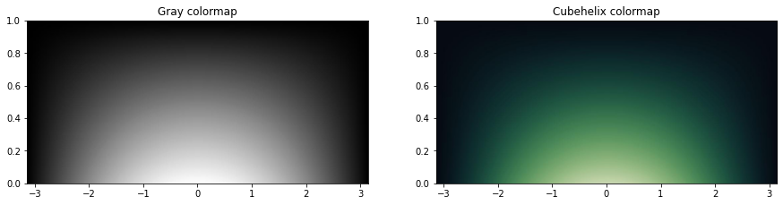

```python
x = np.arange((-np.pi), np.pi, (np.pi*2)/1024)
y = np.arange(0., 1., (1./512))
X, Y = np.meshgrid(x, y)

def fun(a, b):
    return b*np.cos(a/2)

Z = fun(X, Y)

# Let the value 0 correspond to 0 and 1.0 to 255.
Z *= 255

# float to int
Z = Z.astype(int)

# save as images
plt.imsave('grayScaleFunc.jpg', Z, cmap='gray')
plt.imsave('cubehelixScaleFunc.jpg', Z, cmap=cubehelix_palette)

# plot
plt.figure(figsize=(15, 6))
plt.subplot(121)
trash = plt.imshow(mpimg.imread('grayScaleFunc.jpg'), extent = [-np.pi, np.pi, 0, 1], aspect = 3)
trash = plt.title("Gray colormap")
plt.subplot(122)
trash = plt.imshow(mpimg.imread('cubehelixScaleFunc.jpg'), extent = [-np.pi, np.pi, 0, 1], aspect = 3)
trash = plt.title("Cubehelix colormap")
```

## Task 2: contour plots

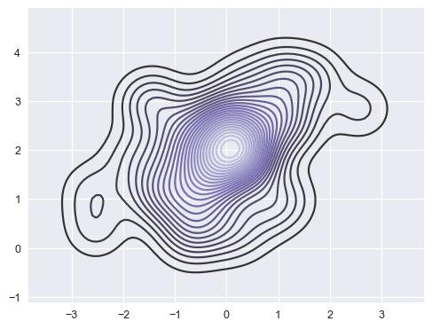

First learn about [contour lines and contour plots at Wikipedia](https://en.wikipedia.org/wiki/Contour_line).

### Question 2.1

What type of data are suitable for visualizing with a contour plot?

### Answer 2.1

A contour plot helps us visualize a three-dimensional surface on a two-dimensional plane. It is suitable if we want to see how some value Z changes as a function of two inputs, X and Y (Z = f(X,Y)). Example of data that commonly is displayed by a contour plot is cartographic, astrological and meteorological data. Contour lines often visualizes altitude, but can aslo be used to visualize brightness, electrical potential and density.

### Task 2.1

Learn about the function `contour` and `contourf` in Matplotlib.

- Make a contour plot of the function in Task 1.3 above.
- Use your own cubehelic colormap together with labels to indicate the values of the level sets.
- Make a second contour plot, where 3 black, thick level-sets curves are included on top of your image plot from Task 1.3. You have to select suitable contour values.

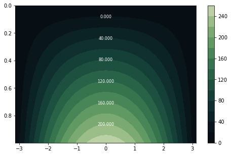

```python
# new figure
fig, ax = plt.subplots(figsize=(8,5))

# plot the function
c = plt.contourf(X, Y, Z, levels = 15, cmap = cubehelix_palette)

# add a colorbar
plt.colorbar(c, ax = c.axes)

# create manual positions for the labels
manual_locations = [(0, 0.05), (0, 0.2), (0, 0.4), (0, 0.55), (0, 0.7), (0, 0.85)]
# add labels to the plot
plt.clabel(c, inline=1, fontsize=8, manual=manual_locations, colors = 'white')
ax.invert_yaxis()
```

[output not shown]

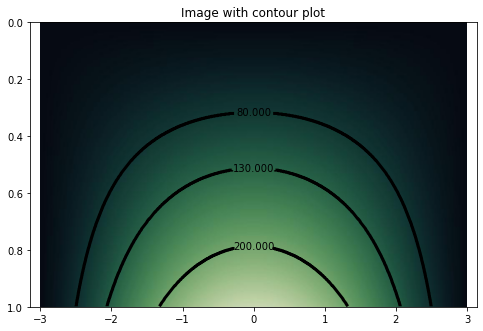

```python
plt.rcParams['contour.negative_linestyle'] = 'solid'
fig, ax = plt.subplots(figsize=(8,20))

im = ax.imshow(mpimg.imread('cubehelixScaleFunc.jpg'), extent=(-3, 3, 0, 1), aspect = 4, origin='lower')
cs = ax.contour(X, Y, Z, levels = [80, 130, 200], colors='k', origin='lower', extend='both', linewidths=3, extent=(-3, 3, 0, 1))
manual_locations = [(0, 0.2), (0, 0.5), (0, 0.7)]
ax.clabel(cs, fontsize=10, inline=True, manual = manual_locations)
ax.set_title('Image with contour plot')
ax.invert_yaxis()
plt.plot
```

## Task 3: vector fields and quiver plots

[figure not shown]

A vector field is, as it says, mapping which to every point in some domain associates a vector. One can think of it in terms of a fluid in motion: at each point the fluid has a certain velocity. Another way of thinking of a vector field is as the right-hand side in a [first order system of ordinary differential equations](https://en.wikipedia.org/wiki/Ordinary_differential_equation#System_of_ODEs).

To plot vector fields in two dimensions in Matplotlib one can use the `quiver` command. First learn about the `quiver` command, for example by studying [this tutorial](https://pythonforundergradengineers.com/quiver-plot-with-matplotlib-and-jupyter-notebooks.html).

### Task 3.1

Study the differential equations for the non-linear pendulum). Make a velocity field plot for the pendulum system written as a first order system

$$ \theta' = v, \qquad v' = -\sin\theta. $$

Use the domain $-\pi \leq \theta \leq \pi$ and $-3\leq v \leq 3$. Put $\theta$ on the $x$-axis and $v$ on the $y$-axis.

Modify the plot, adding color to the arrows corresponding to the magnitude of the velocity vectors. Use your own colormap. (**Hint:** use the `C` input to the `quiver` function).

```
(-3.0, 3.0)
```

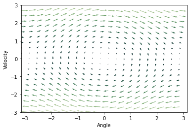

```python
import matplotlib

# function that calculates the derivate
def f(Y):
    y1, y2 = Y
    return [y2, -np.sin(y1)]


theta = np.arange(-np.pi, np.pi, 0.3)
v = np.arange(-3, 3, 0.3)

T, V = np.meshgrid(theta, v)

t_dir, v_dir = np.zeros(T.shape), np.zeros(V.shape)

I, J = T.shape

for i in range(I):
    for j in range(J):
        x = T[i, j]
        y = V[i, j]
        yprime = f([x, y])
        t_dir[i,j] = yprime[0]
        v_dir[i,j] = yprime[1]

# magnitude of the arrows
mag = np.hypot(t_dir, v_dir)
q = plt.quiver(T, V, t_dir, v_dir, mag, cmap = cubehelix_palette)

plt.xlabel('Angle')
plt.ylabel('Velocity')
plt.xlim([-np.pi, np.pi])
plt.ylim([-3, 3])
```

## Task 4: stream plots

Thinking of a vector field as the right hand side of an ordinary differential equation, a *stream plot* shows one or several curves integrating (solving) this ODE. Each such curve is called a [*stream line*](https://en.wikipedia.org/wiki/Streamlines,_streaklines,_and_pathlines). Start by learning how to use the `streamplot` function in Matplotlib (find a suitable online tutorial).

### Task 4.1

Make a streamline plot for the pendulum system in Task 3.1. Use your own color map to indicate velocity. Try to interpret what you see in term of physics of the pendulum motion: Where is the velocity high? Why? What does it mean (in terms of motion of the pendulum) that some curves are circular and some are not? Learn the meaning of the `start_points` argument to the `streamplot` function. Use this to generate streamlines that originates from specific points on the positive $y$-axis.

### Answer 4.1

The velocity is high when $\theta$ is zero, because that is when the velocity of pendelum get as highest (when the pendelum is at the 'bottom', and this is because of the gravity).

Some curves creates circular shapes and some do not. The ones that are circular shows the pendelum motion, that by "swinging" back and forth. The velocity direction points in a positive direction when the pendelum is going one way and it points in a negative direction when the pendelum is going the other way. The curves that are not connected and just points at one direction are visualizing when the velocity is high enough to keep the pendelum going in just one direction (circular).

By the smaller circular curves, that are in the middle of the streamline plot, we can tell that the angle of the pendelum does not get very high and that is because of the low velocity.

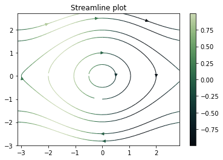

```python
# code for streamline plot
fig, ax = plt.subplots()
start = [[-3, 0], [-3, 2], [-2, 0], [-3, -2], [-0.5, 0], [0, -2.5],  [0, -1], [0, 2.5], [2.8, 2]]
strm = plt.streamplot(T, V, t_dir, v_dir, linewidth=1, color=v_dir, cmap=cubehelix_palette, start_points=start)
fig.colorbar(strm.lines)
plt.title("Streamline plot")
```

### Task 4.2

Make a contour plot for the function $f(\theta,v) = v^2/2 - \cos \theta$ for the same domain as in Task 3.1. Compare with the streamline plot for the pendulum system (previous task). What do you observe? Can you explain your observations?

### Answer 4.1

The two plots look quite similar to each other.

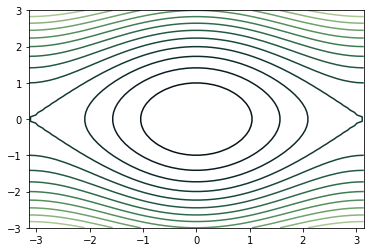

```python
fig, ax = plt.subplots()

x = np.linspace(-np.pi, np.pi)
y = np.linspace(-3,3)
X, Y = np.meshgrid(x, y)
Z=Y**2/2-np.cos(X)

ax.contour(X,Y,Z, levels=15, cmap = cubehelix_palette)
```